# EDA_2

Alejandro Perela

20/11/2021

## Definición de objetivos

El principal objetivo de este análisis es la predicción de si un cliente contratará o no el producto antes de realizar la llamada.

Para ello, vamos a analizar las diferentes variables para ver cómo es su distribución, la calidad de sus datos y cómo es la relación entre ellas.

## Análisis exploratorio inicial

Primero, cargamos las librerías que vamos a necesitar a lo largo del análisis

```r
library(dplyr)
library(GGally)
library(VIM)
library(Hmisc)
library(ggplot2)
library(scales)
library(creditmodel)
```

Diccionario con la definición de los diferentes campos que incluye el dataset

1 - **age** (numeric)  
2 - **job**: type of job (categorical: “admin.”,“blue-collar”,“entrepreneur”,“housemaid”,“management”,“retired”,“self-employed”,“services”,“student”,“technician”,“unemployed”,“unknown”)  
3 - **marital**: marital status (categorical: “divorced”,“married”,“single”,“unknown”; note: “divorced” means divorced or widowed)  
4 - **education** (categorical: “basic.4y”,“basic.6y”,“basic.9y”,“high.school”,“illiterate”,“professional.course”,“university.degree”,“unknown”)  
5 - **default**: has credit in default? (categorical: “no”,“yes”,“unknown”)  
6 - **housing**: has housing loan? (categorical: “no”,“yes”,“unknown”)  
7 - **loan**: has personal loan? (categorical: “no”,“yes”,“unknown”)  
# related with the last contact of the current campaign:  
8 - **contact**: contact communication type (categorical: “cellular”,“telephone”)  
9 - **month**: last contact month of year (categorical: “jan”, “feb”, “mar”, …, “nov”, “dec”)  
10 - **day_of_week**: last contact day of the week (categorical: “mon”,“tue”,“wed”,“thu”,“fri”)  
11 - **duration**: last contact duration, in seconds (numeric). Important note: this attribute highly affects the output target (e.g., if duration=0 then y=“no”). Yet, the duration is not known before a call is performed. Also, after the end of the call y is obviously known. Thus, this input should only be included for benchmark purposes and should be discarded if the intention is to have a realistic predictive model.  
# other attributes:  
12 - **campaign**: number of contacts performed during this campaign and for this client (numeric, includes last contact)  
13 - **pdays**: number of days that passed by after the client was last contacted from a previous campaign (numeric; 999 means client was not previously contacted)  
14 - **previous**: number of contacts performed before this campaign and for this client (numeric)  
15 - **poutcome**: outcome of the previous marketing campaign (categorical: “failure”,“nonexistent”,“success”)  
# social and economic context attributes  
16 - **emp.var.rate**: employment variation rate - quarterly indicator (numeric)  
17 - **cons.price.idx**: consumer price index - monthly indicator (numeric)  
18 - **cons.conf.idx**: consumer confidence index - monthly indicator (numeric)  
19 - **euribor3m**: euribor 3 month rate - daily indicator (numeric)  
20 - **nr.employed**: number of employees - quarterly indicator (numeric)

Output variable (desired target):  
21 - **y** - has the client subscribed a term deposit? (binary: “yes”,“no”)

Cargamos los datos para trabajar sobre ellos

```r
#folder = '/home/alejandro/Documents/Master Data Science/Curso/Fundamentos del análisis de datos/Trabajo grupo/data/bank-additional/bank-additional.csv'
data <- read.csv(file='../data/bank-additional/bank-additional.csv', sep=';')
head(data)
```

|  | age | job | marital | education | default | housing | loan | contact | month | day_of_week | duration | campaign | pdays | previous | poutcome | emp.var.rate | cons.price.idx | cons.conf.idx | euribor3m | nr.employed | y |
| --- | --- | --- | --- | --- | --- | --- | --- | --- | --- | --- | --- | --- | --- | --- | --- | --- | --- | --- | --- | --- | --- |
| 1 | 30 | blue-collar | married | basic.9y | no | yes | no | cellular | may | fri | 487 | 2 | 999 | 0 | nonexistent | -1.8 | 92.893 | -46.2 | 1.313 | 5099.1 | no |
| 2 | 39 | services | single | high.school | no | no | no | telephone | may | fri | 346 | 4 | 999 | 0 | nonexistent | 1.1 | 93.994 | -36.4 | 4.855 | 5191.0 | no |
| 3 | 25 | services | married | high.school | no | yes | no | telephone | jun | wed | 227 | 1 | 999 | 0 | nonexistent | 1.4 | 94.465 | -41.8 | 4.962 | 5228.1 | no |
| 4 | 38 | services | married | basic.9y | no | unknown | unknown | telephone | jun | fri | 17 | 3 | 999 | 0 | nonexistent | 1.4 | 94.465 | -41.8 | 4.959 | 5228.1 | no |
| 5 | 47 | admin. | married | university.degree | no | yes | no | cellular | nov | mon | 58 | 1 | 999 | 0 | nonexistent | -0.1 | 93.200 | -42.0 | 4.191 | 5195.8 | no |
| 6 | 32 | services | single | university.degree | no | no | no | cellular | sep | thu | 128 | 3 | 999 | 2 | failure | -1.1 | 94.199 | -37.5 | 0.884 | 4963.6 | no |

```r
str(data)
```

```
## 'data.frame':    4119 obs. of  21 variables:
##  $ age           : int  30 39 25 38 47 32 32 41 31 35 ...
##  $ job           : chr  "blue-collar" "services" "services" "services" ...
##  $ marital       : chr  "married" "single" "married" "married" ...
##  $ education     : chr  "basic.9y" "high.school" "high.school" "basic.9y" ...
##  $ default       : chr  "no" "no" "no" "no" ...
##  $ housing       : chr  "yes" "no" "yes" "unknown" ...
##  $ loan          : chr  "no" "no" "no" "unknown" ...
##  $ contact       : chr  "cellular" "telephone" "telephone" "telephone" ...
##  $ month         : chr  "may" "may" "jun" "jun" ...
##  $ day_of_week   : chr  "fri" "fri" "wed" "fri" ...
##  $ duration      : int  487 346 227 17 58 128 290 44 68 170 ...
##  $ campaign      : int  2 4 1 3 1 3 4 2 1 1 ...
##  $ pdays         : int  999 999 999 999 999 999 999 999 999 999 ...
##  $ previous      : int  0 0 0 0 0 2 0 0 1 0 ...
##  $ poutcome      : chr  "nonexistent" "nonexistent" "nonexistent" "nonexistent" ...
##  $ emp.var.rate  : num  -1.8 1.1 1.4 1.4 -0.1 -1.1 -1.1 -0.1 -0.1 1.1 ...
##  $ cons.price.idx: num  92.9 94 94.5 94.5 93.2 ...
##  $ cons.conf.idx : num  -46.2 -36.4 -41.8 -41.8 -42 -37.5 -37.5 -42 -42 -36.4 ...
##  $ euribor3m     : num  1.31 4.86 4.96 4.96 4.19 ...
##  $ nr.employed   : num  5099 5191 5228 5228 5196 ...
##  $ y             : chr  "no" "no" "no" "no" ...
```

Parece que todas las columnas tienen el tipo de datos correcto, por lo que continuamos analizando los diferentes valores que toman las dimensiones cualitativas

**job**

```r
data %>% group_by(y, job) %>% summarise(registers = n(), .groups = 'drop')
```

| y | job | registers |
| --- | --- | --- |
| no | admin. | 879 |
| no | blue-collar | 823 |
| no | entrepreneur | 140 |
| no | housemaid | 99 |
| no | management | 294 |
| no | retired | 128 |
| no | self-employed | 146 |
| no | services | 358 |
| no | student | 63 |
| no | technician | 611 |

[output cut: 14 more lines]

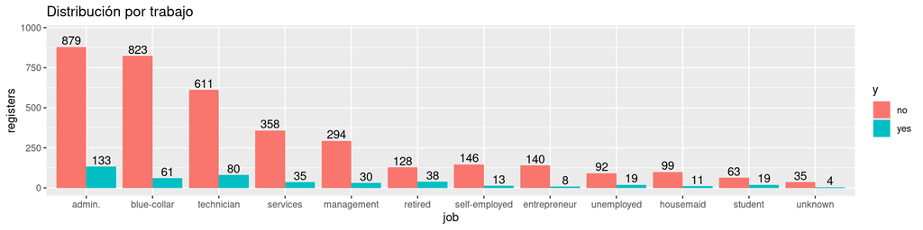

```r
ggplot(data %>% group_by(y, job) %>% summarise(registers = n(), .groups = 'drop'),
       aes(x = reorder(job, -registers), y=registers, fill=y, ymax=registers*1.1)) +
  geom_bar(stat = "identity", position = "dodge") +
  xlab("job") +
  geom_text(stat='identity', aes(label=registers), vjust=-0.25, position = position_dodge(width = .9)) +
  ggtitle("Distribución por trabajo")
```

**marital**

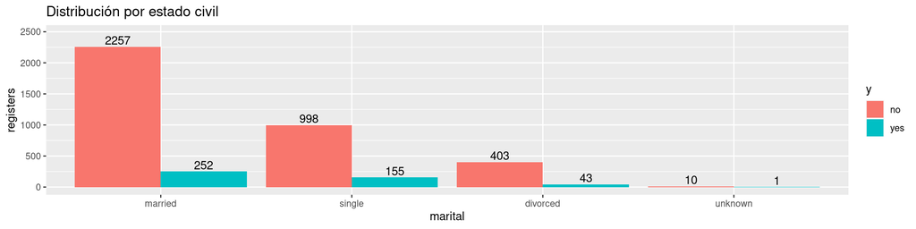

```r
ggplot(data %>% group_by(y, marital) %>% summarise(registers = n(), .groups = 'drop'),
       aes(x = reorder(marital, -registers), y=registers, fill=y, ymax=registers*1.1)) +
  geom_bar(stat = "identity", position = "dodge") +
  xlab("marital") +
  geom_text(stat='identity', aes(label=registers), vjust=-0.25, position = position_dodge(width = .9)) +
  ggtitle("Distribución por estado civil")
```

**education**

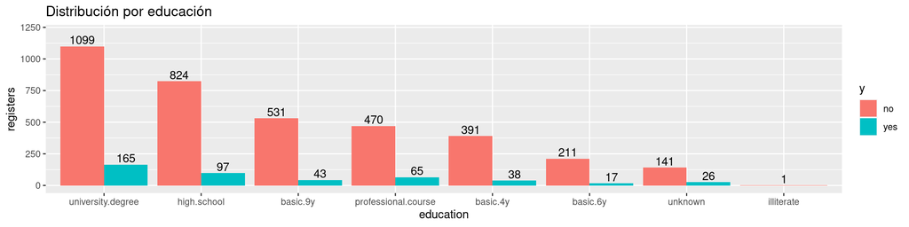

```r
ggplot(data %>% group_by(y, education) %>% summarise(registers = n(), .groups = 'drop'),
       aes(x = reorder(education, -registers), y=registers, fill=y, ymax=registers*1.1)) +
  geom_bar(stat = "identity", position = "dodge") +
  xlab("education") +
  geom_text(stat='identity', aes(label=registers), vjust=-0.25, position = position_dodge(width = .9)) +
  ggtitle("Distribución por educación")
```

**default**

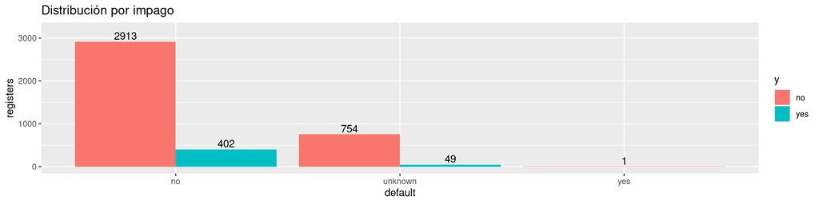

```r
ggplot(data %>% group_by(y, default) %>% summarise(registers = n(), .groups = 'drop'),
       aes(x = reorder(default, -registers), y=registers, fill=y, ymax=registers*1.1)) +
  geom_bar(stat = "identity", position = "dodge") +
  xlab("default") +
  geom_text(stat='identity', aes(label=registers), vjust=-0.25, position = position_dodge(width = .9)) +
  ggtitle("Distribución por impago")
```

**housing**

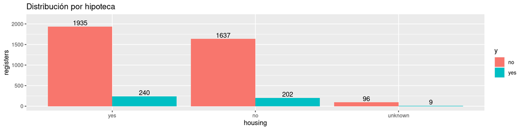

```r
ggplot(data %>% group_by(y, housing) %>% summarise(registers = n(), .groups = 'drop'),
       aes(x = reorder(housing, -registers), y=registers, fill=y, ymax=registers*1.1)) +
  geom_bar(stat = "identity", position = "dodge") +
  xlab("housing") +
  geom_text(stat='identity', aes(label=registers), vjust=-0.25, position = position_dodge(width = .9)) +
  ggtitle("Distribución por hipoteca")
```

**loan**

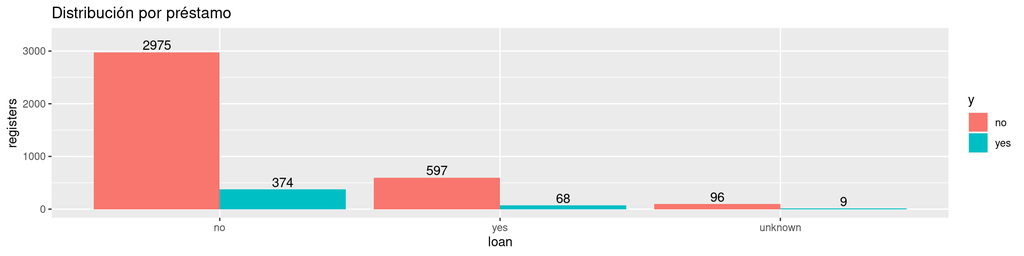

```r
ggplot(data %>% group_by(y, loan) %>% summarise(registers = n(), .groups = 'drop'),
       aes(x = reorder(loan, -registers), y=registers, fill=y, ymax=registers*1.1)) +
  geom_bar(stat = "identity", position = "dodge") +
  xlab("loan") +
  geom_text(stat='identity', aes(label=registers), vjust=-0.25, position = position_dodge(width = .9)) +
  ggtitle("Distribución por préstamo")
```

**contact**

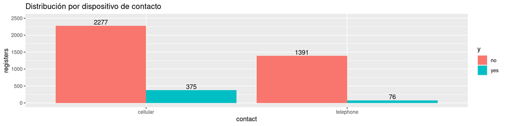

```r
ggplot(data %>% group_by(y, contact) %>% summarise(registers = n(), .groups = 'drop'),
       aes(x = reorder(contact, -registers), y=registers, fill=y, ymax=registers*1.1)) +
  geom_bar(stat = "identity", position = "dodge") +
  xlab("contact") +
  geom_text(stat='identity', aes(label=registers), vjust=-0.25, position = position_dodge(width = .9)) +
  ggtitle("Distribución por dispositivo de contacto")
```

**month**

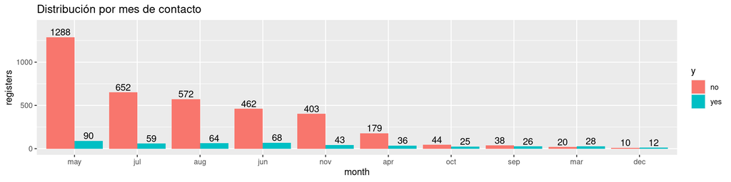

```r
ggplot(data %>% group_by(y, month) %>% summarise(registers = n(), .groups = 'drop'),
       aes(x = reorder(month, -registers), y=registers, fill=y, ymax=registers*1.1)) +
  geom_bar(stat = "identity", position = "dodge") +
  xlab("month") +
  geom_text(stat='identity', aes(label=registers), vjust=-0.25, position = position_dodge(width = .9)) +
  ggtitle("Distribución por mes de contacto")
```

**day_of_week**

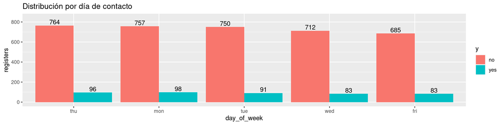

```r
ggplot(data %>% group_by(y, day_of_week) %>% summarise(registers = n(), .groups = 'drop'),
       aes(x = reorder(day_of_week, -registers), y=registers, fill=y, ymax=registers*1.1)) +
  geom_bar(stat = "identity", position = "dodge") +
  xlab("day_of_week") +
  geom_text(stat='identity', aes(label=registers), vjust=-0.25, position = position_dodge(width = .9)) +
  ggtitle("Distribución por día de contacto")
```

**poutcome**

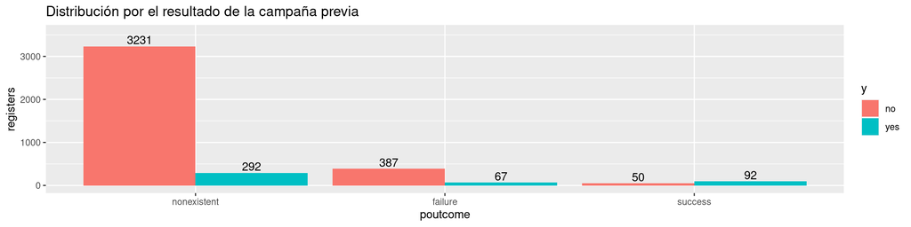

```r
ggplot(data %>% group_by(y, poutcome) %>% summarise(registers = n(), .groups = 'drop'),
       aes(x = reorder(poutcome, -registers), y=registers, fill=y, ymax=registers*1.1)) +
  geom_bar(stat = "identity", position = "dodge") +
  xlab("poutcome") +
  geom_text(stat='identity', aes(label=registers), vjust=-0.25, position = position_dodge(width = .9)) +
  ggtitle("Distribución por el resultado de la campaña previa")
```

**y**

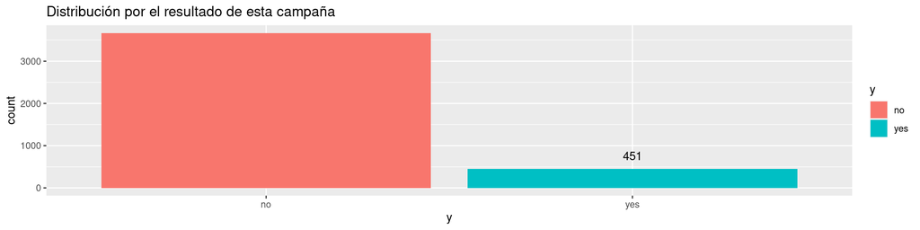

```r
ggplot(data, aes(x = reorder(y, y, function(x)-length(x)), fill=y)) +
  geom_bar() +
  xlab("y") +
  geom_text(stat='count', aes(label=..count..), vjust=-1) +
  ggtitle("Distribución por el resultado de esta campaña")
```

Una vez conocemos los diferentes valores que toman las dimensiones de nuestro dataset, sustituimos los valores unkown por NA, para poder trabajar con datos faltantes

```r
data$job[data$job=='unknown'] <- NA
data$marital[data$marital=='unknown'] <- NA
data$education[data$education=='unknown'] <- NA
data$default[data$default=='unknown'] <- NA
data$housing[data$housing=='unknown'] <- NA
data$loan[data$loan=='unknown'] <- NA
```

Una vez hehco esto, visualizamos el porcentaje de valores nulos que hay en nuestros datos, así como la combinación de valores nulos entre las diferentes dimensiones

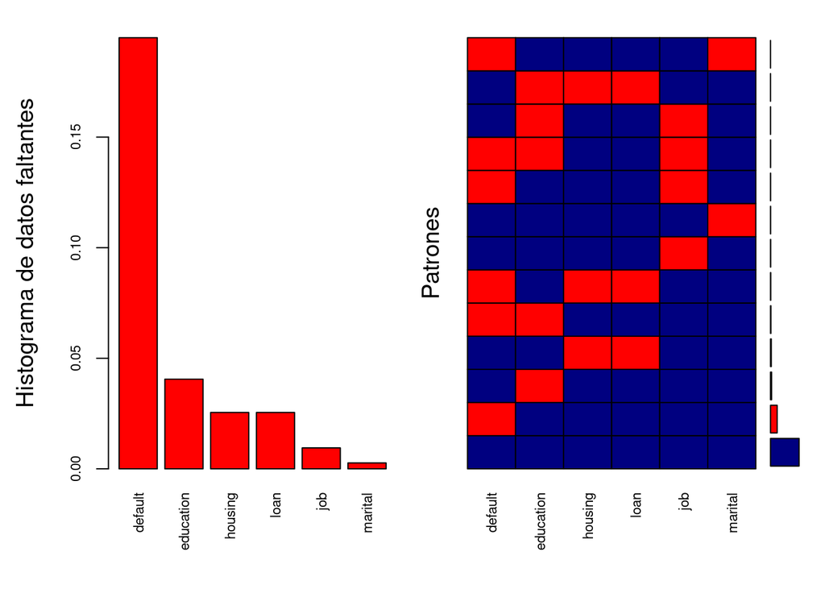

```
##
##  Variables sorted by number of missings:
##   Variable       Count
##    default 0.194950231
##  education 0.040543821
##    housing 0.025491624
##       loan 0.025491624
##        job 0.009468318
##    marital 0.002670551
```

```r
aggr_plot <- aggr(data[,2:7], col=c('navyblue','red'), numbers=TRUE, sortVars=TRUE,
                  labels=names(data[,2:7]), cex.axis=.7, gap=3,
                  ylab=c("Histograma de datos faltantes","Patrones"))
```

Ya podemos separar entre el train y test, dado que ya hemos hecho la limpieza de datos pertinente

```r
train_test = train_test_split(data,
                              split_type = "Random",
                              prop = 0.75)
data_train = train_test$train
data_test = train_test$test
```

Una vez conocemos cómo se distribuyen los datos cualitativos, contiuamos analizando los datos cuantitativos, de forma tanto descriptiva como con visualizaciones

```r
summary(data_train)
```

```
##       age            job              marital           education
##  Min.   :18.00   Length:3089        Length:3089        Length:3089
##  1st Qu.:32.00   Class :character   Class :character   Class :character
##  Median :38.00   Mode  :character   Mode  :character   Mode  :character
##  Mean   :40.12
##  3rd Qu.:47.00
##  Max.   :86.00
##    default            housing              loan             contact
##  Length:3089        Length:3089        Length:3089        Length:3089
##  Class :character   Class :character   Class :character   Class :character
##  Mode  :character   Mode  :character   Mode  :character   Mode  :character
##
##
##
##     month           day_of_week           duration         campaign
##  Length:3089        Length:3089        Min.   :   5.0   Min.   : 1.000
##  Class :character   Class :character   1st Qu.: 103.0   1st Qu.: 1.000
##  Mode  :character   Mode  :character   Median : 180.0   Median : 2.000
##                                        Mean   : 258.2   Mean   : 2.589
##                                        3rd Qu.: 318.0   3rd Qu.: 3.000
##                                        Max.   :3643.0   Max.   :35.000
##      pdays          previous        poutcome          emp.var.rate
##  Min.   :  0.0   Min.   :0.0000   Length:3089        Min.   :-3.40000
##  1st Qu.:999.0   1st Qu.:0.0000   Class :character   1st Qu.:-1.80000
##  Median :999.0   Median :0.0000   Mode  :character   Median : 1.10000
##  Mean   :960.4   Mean   :0.1884                      Mean   : 0.08258
##  3rd Qu.:999.0   3rd Qu.:0.0000                      3rd Qu.: 1.40000
##  Max.   :999.0   Max.   :6.0000                      Max.   : 1.40000
##  cons.price.idx  cons.conf.idx      euribor3m      nr.employed
##  Min.   :92.20   Min.   :-50.80   Min.   :0.635   Min.   :4964
##  1st Qu.:93.08   1st Qu.:-42.70   1st Qu.:1.334   1st Qu.:5099
##  Median :93.75   Median :-41.80   Median :4.857   Median :5191
##  Mean   :93.58   Mean   :-40.54   Mean   :3.620   Mean   :5167
##  3rd Qu.:93.99   3rd Qu.:-36.40   3rd Qu.:4.961   3rd Qu.:5228
##  Max.   :94.77   Max.   :-26.90   Max.   :5.045   Max.   :5228
##       y
##  Length:3089
##  Class :character
##  Mode  :character
##
##
##
```

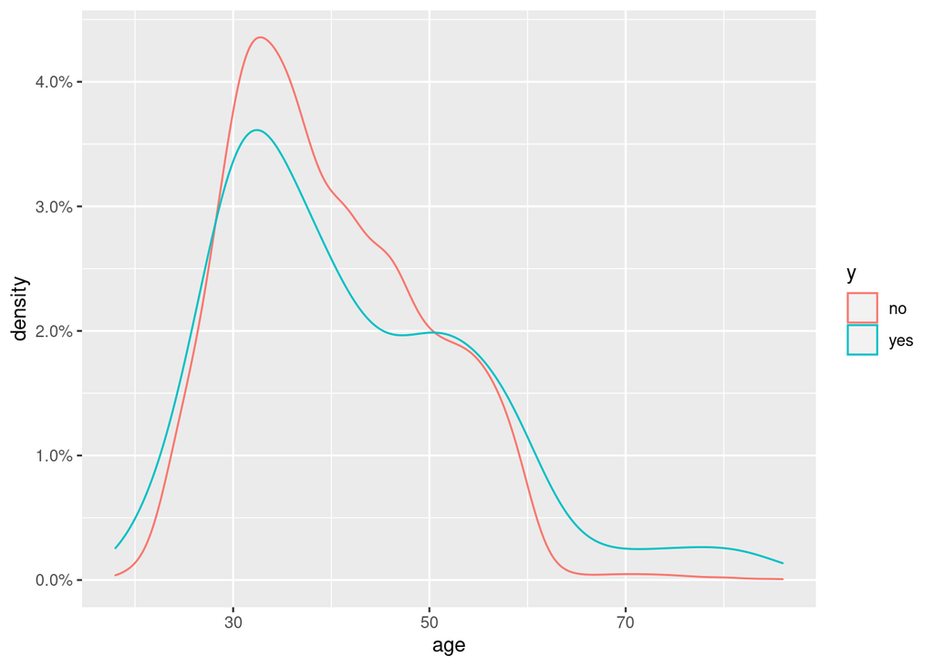

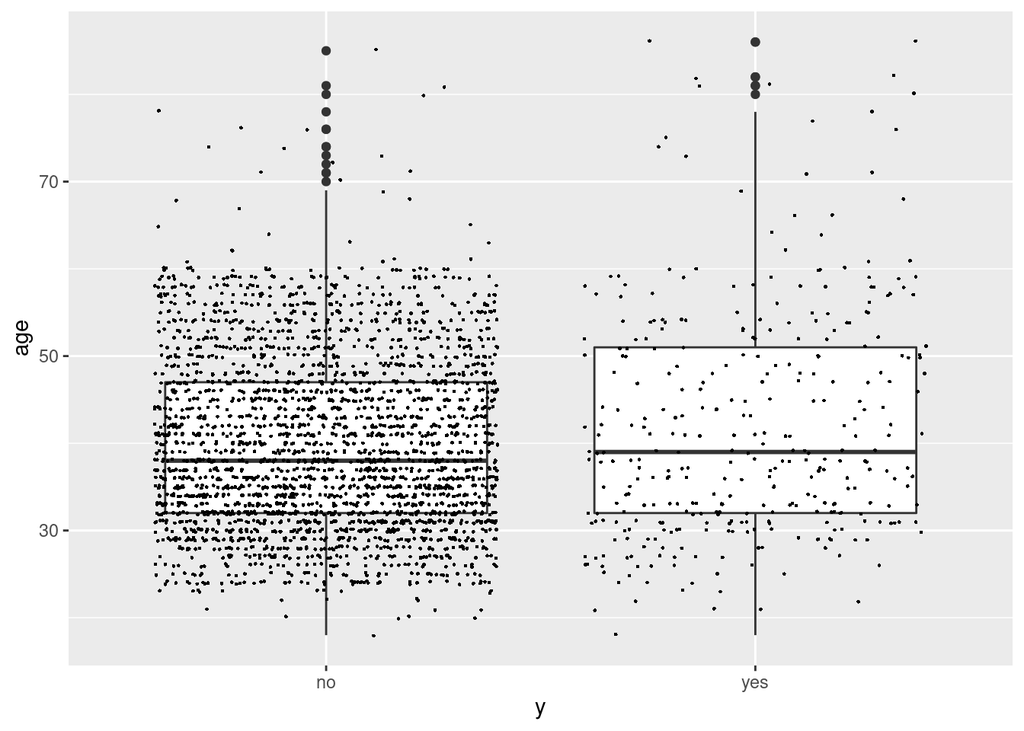

```r
ggplot(data_train, aes(x=age, color=y)) +
  geom_density() +
  scale_y_continuous(labels = scales::percent) +
  scale_x_continuous(labels = comma)

ggplot(data_train, aes(x=age, y=y)) +
  geom_boxplot() +
  coord_flip() +
  geom_jitter(shape=16, position=position_jitter(0.2), size=0.5)
```

Como podemos observar en la gráfica de densidad, parece que las personas que terminan contratando son ligeramente más mayores que las que no. Y de hecho, como podemos ver en el gráfico de cajas, las edades son de media más bajas y están menos dispersas para las personas que no contratan.

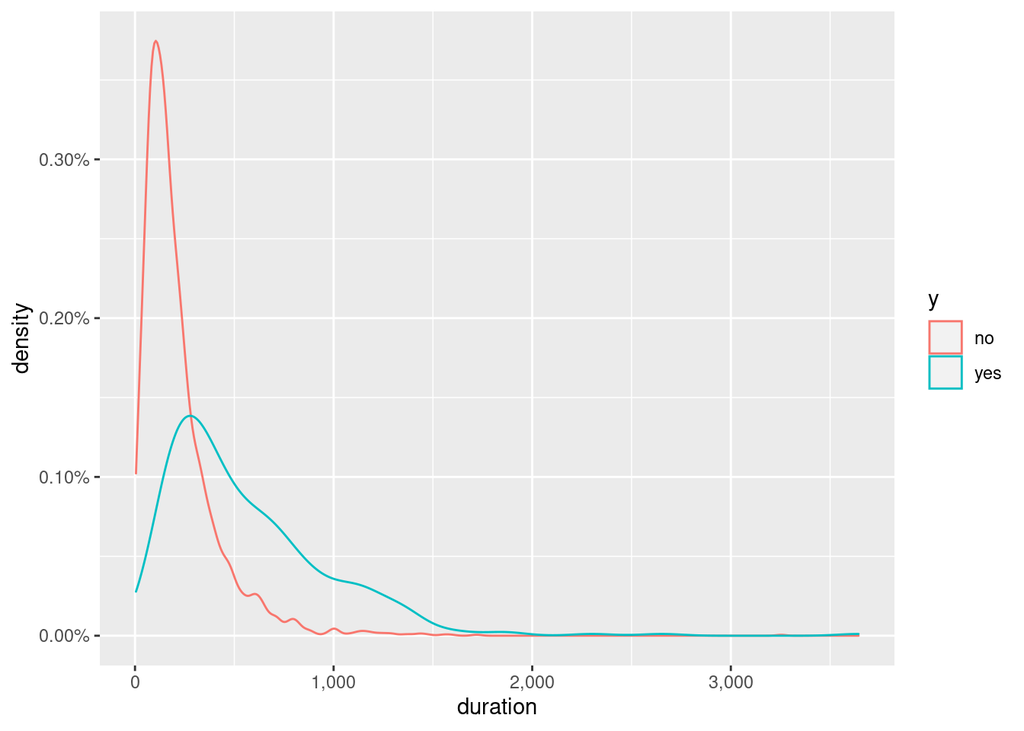

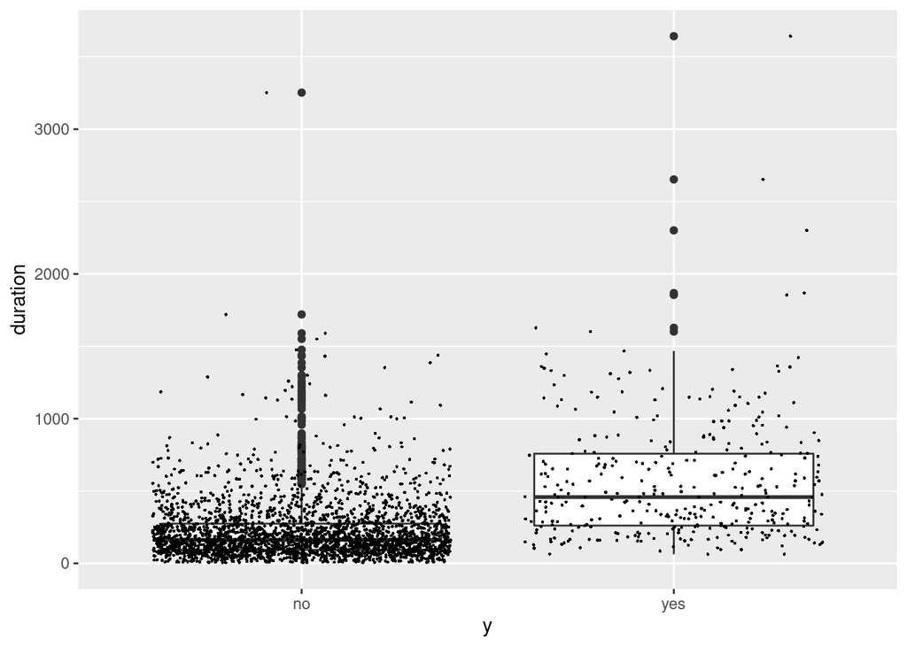

```r
ggplot(data_train, aes(x=duration, color=y)) +
  geom_density() +
  scale_y_continuous(labels = scales::percent) +
  scale_x_continuous(labels = comma)

ggplot(data_train, aes(x=duration, y=y)) +
  geom_boxplot() +
  coord_flip() +
  geom_jitter(shape=16, position=position_jitter(0.2), size=0.5)
```

En este caso, únicamente confirmamos lo que ya sospechábamos, y es que cuanto mayor es la duración de la llamada, mayor es la proporción de personas que termina contratando. La dispersión también es mayor en el caso de la gente que contrata

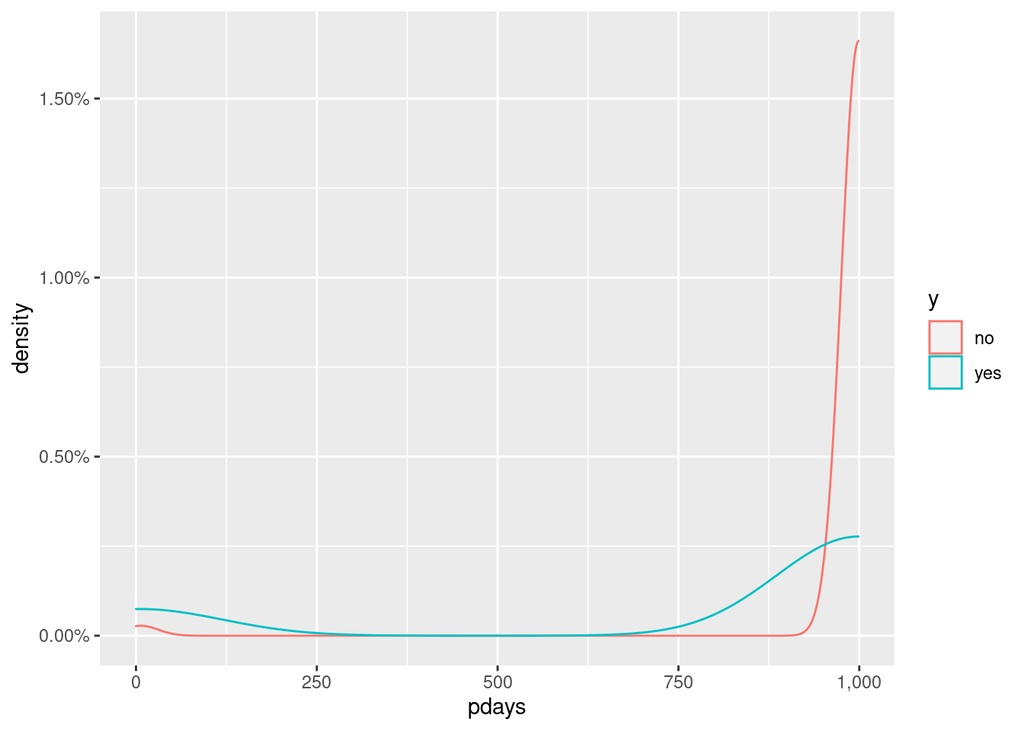

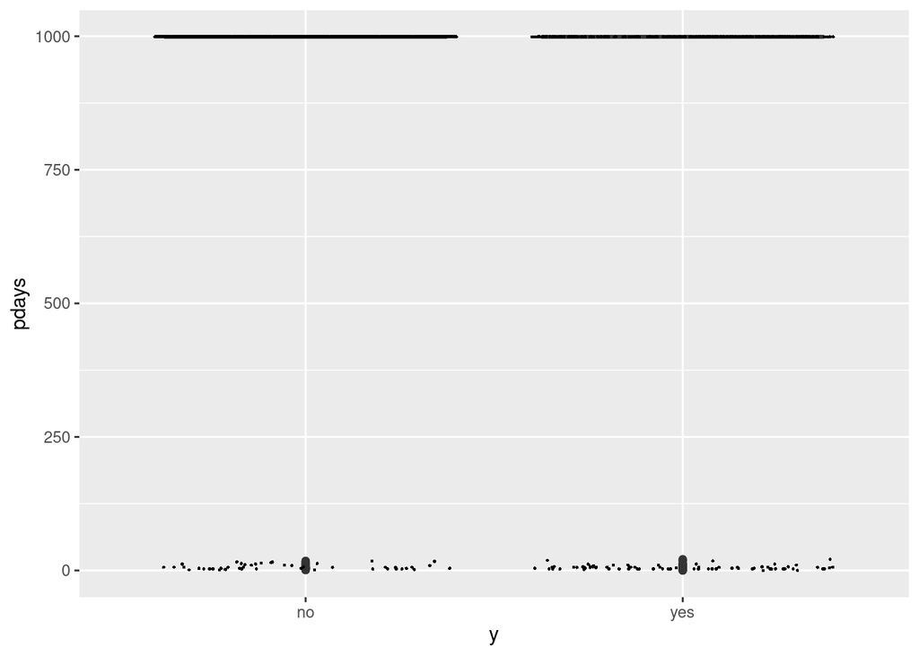

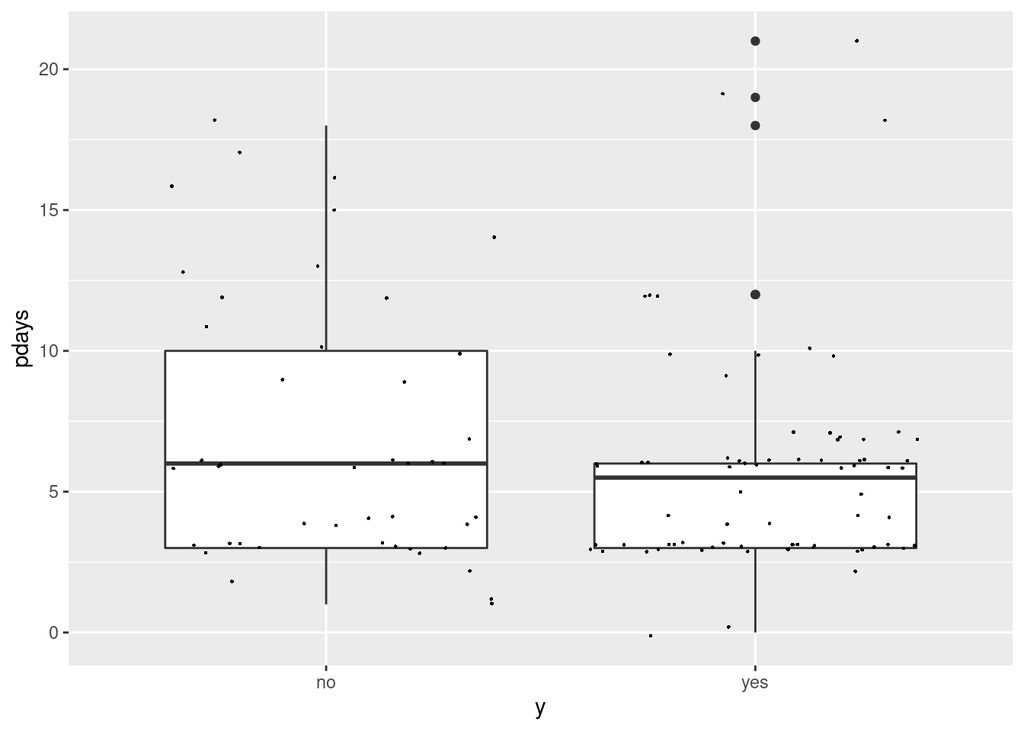

```r
ggplot(data_train, aes(x=pdays, color=y)) +
  geom_density() +
  scale_y_continuous(labels = scales::percent) +
  scale_x_continuous(labels = comma)

ggplot(data_train, aes(x=pdays, y=y)) +
  geom_boxplot() +
  coord_flip() +
  geom_jitter(shape=16, position=position_jitter(0.2), size=0.5)

ggplot(data_train %>% filter(pdays!=999),
       aes(x=pdays, y=y)) +
  geom_boxplot() +
  coord_flip() +
  geom_jitter(shape=16, position=position_jitter(0.2), size=0.5)
```

Antes de nada, se debe comentar que el valor 999 corresponde a gente que nunca se le ha contactado previamente.

En este caso, parece que hay una concentración muy alta de la gente a la que no se ha contactado nunca dentro de la gente que no ha contratado. Sin embargo, si miramos a la gente que sí que contrata, podemos ver que parece que hay una concentración mayor en las personas que se les contactó entre hace 750 días y “1000” días.

Dado que si tenemos en cuenta a las personas que nunca fueron contactadas el boxplot no es interpretable, plasmamos otro filtrando para que no contengan estos registros. Y nos podemos dar cuenta de que hemos malinterpretado el gráfico de densidad, y que se debe a una alta concentración de valores que nunca han sido contactados. De acuerdo a este último boxplot, la media entre ambos grupos es muy similar, aunque para la gente que no termina contratando los datos son un poco más dispersos.

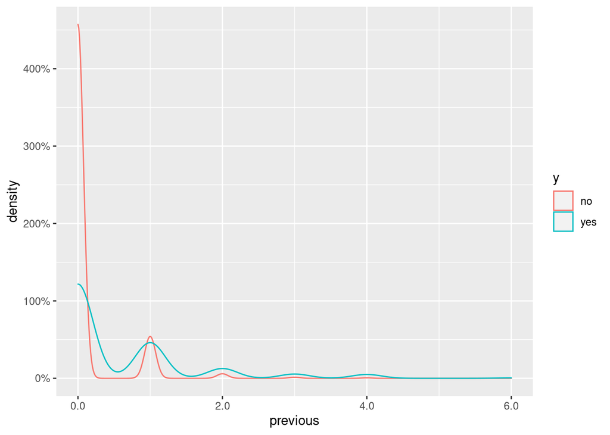

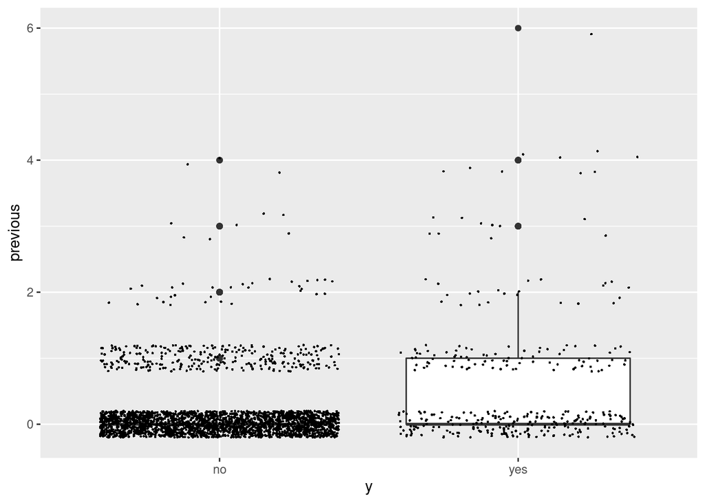

```r
ggplot(data_train, aes(x=previous, color=y)) +
  geom_density() +
  scale_y_continuous(labels = scales::percent) +
  scale_x_continuous(labels = comma)

ggplot(data_train, aes(x=previous, y=y)) +
  geom_boxplot() +
  coord_flip() +
  geom_jitter(shape=16, position=position_jitter(0.2), size=0.5)
```

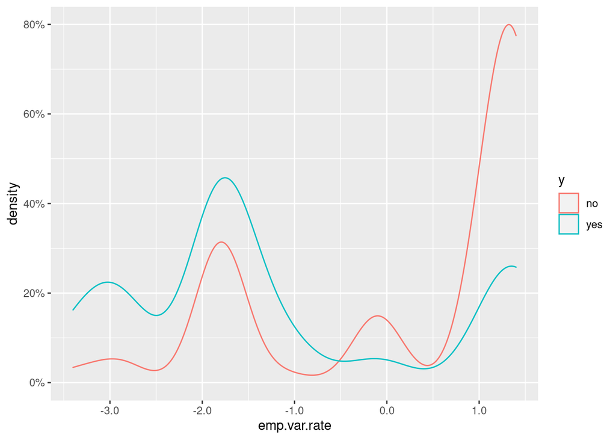

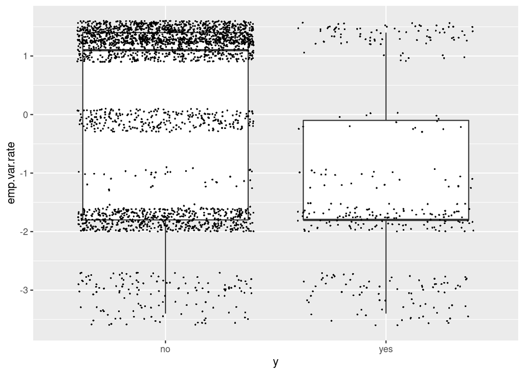

```r
ggplot(data_train, aes(x=emp.var.rate, color=y)) +
  geom_density() +
  scale_y_continuous(labels = scales::percent) +
  scale_x_continuous(labels = comma)

ggplot(data_train, aes(x=emp.var.rate, y=y)) +
  geom_boxplot() +
  coord_flip() +
  geom_jitter(shape=16, position=position_jitter(0.2), size=0.5)
```

Parece que cuanto más aumenta el empleo, mayor es la proporción de personas que no termina contratando, lo cual podemos confirmar con el gráfico de cajas. Cuanto más positiva es la variación en el empleo, menos gente contrata, lo cual podría estar relacionado con que la gente tenga menos necesidad de contratar cuando las condiciones macro son mejores

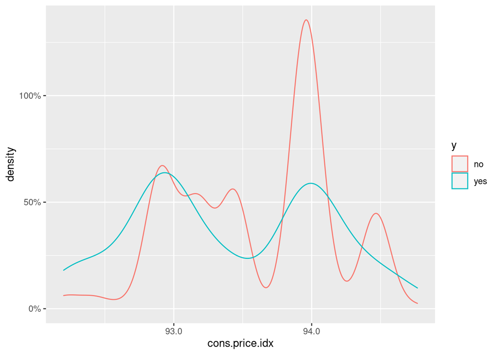

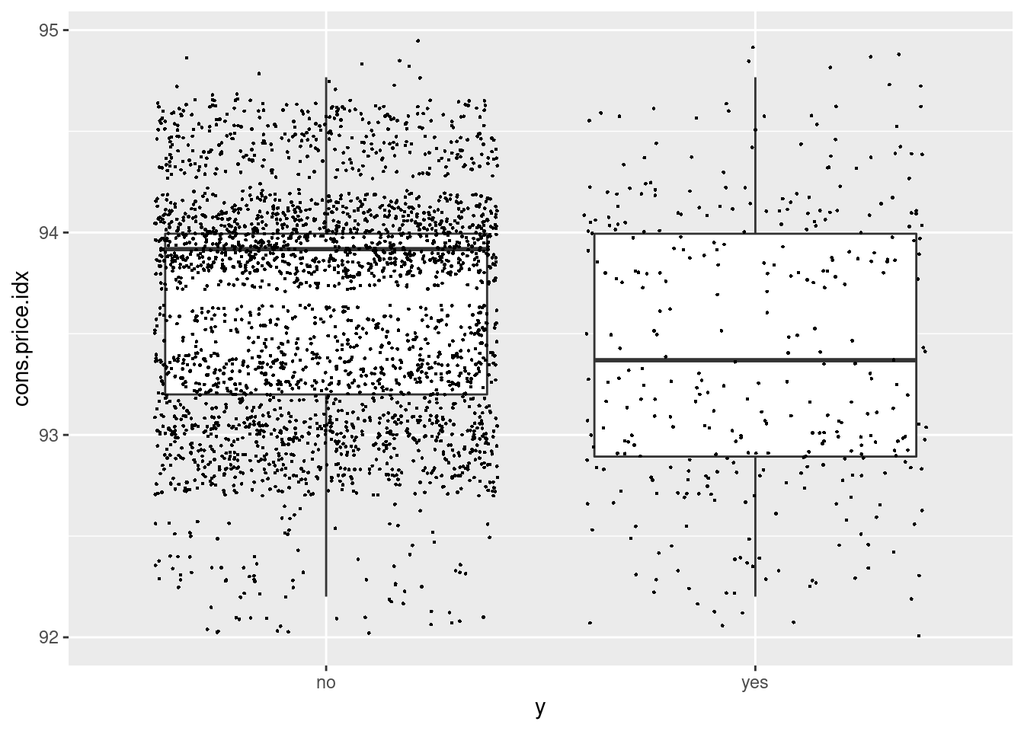

```r
ggplot(data_train, aes(x=cons.price.idx, color=y)) +
  geom_density() +
  scale_y_continuous(labels = scales::percent) +
  scale_x_continuous(labels = comma)

ggplot(data_train, aes(x=cons.price.idx, y=y)) +
  geom_boxplot() +
  coord_flip() +
  geom_jitter(shape=16, position=position_jitter(0.2), size=0.5)
```

Viendo las gráficas de densidad, no parece que haya una relación lógica entre ambas variables, pero viendo el boxplot nos damos cuenta de que como antes, cuantos mejor es el indicador macro, menor es la cantidad de gente que contrata el producto

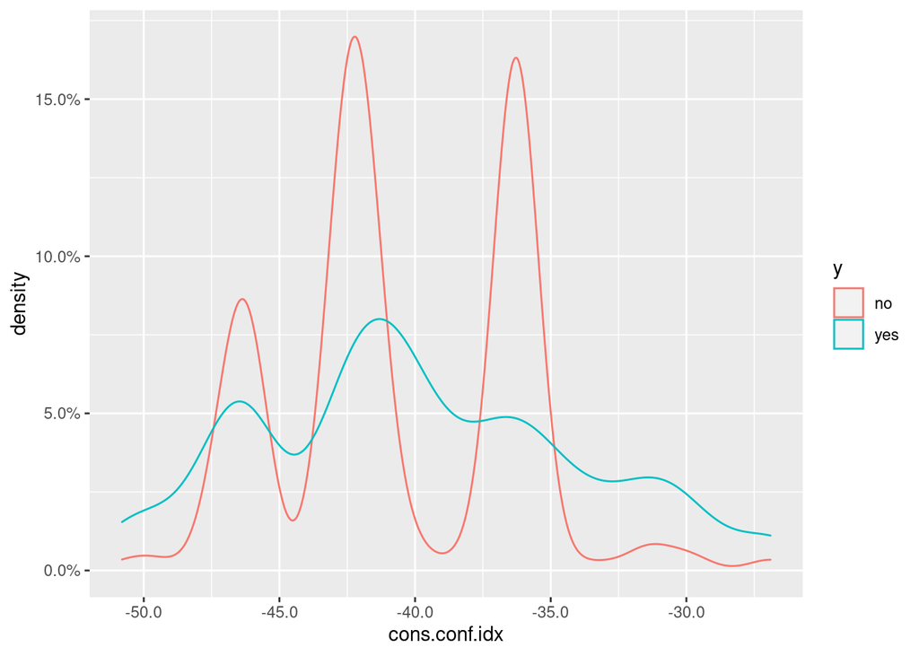

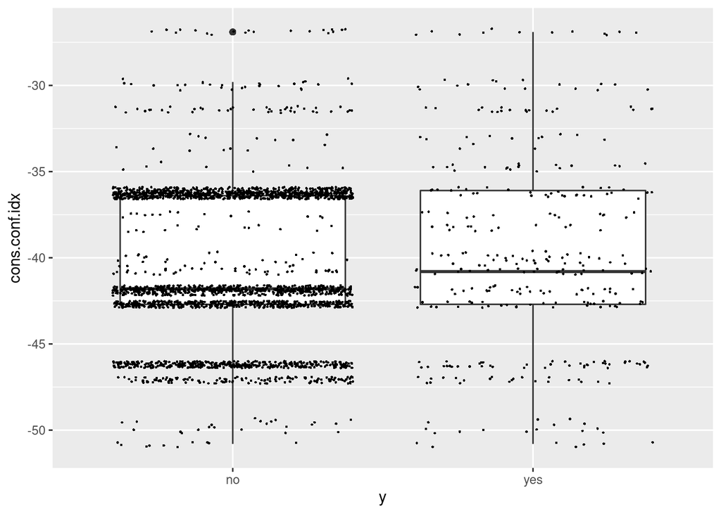

```r
ggplot(data_train, aes(x=cons.conf.idx, color=y)) +
  geom_density() +
  scale_y_continuous(labels = scales::percent) +
  scale_x_continuous(labels = comma)

ggplot(data_train, aes(x=cons.conf.idx, y=y)) +
  geom_boxplot() +
  coord_flip() +
  geom_jitter(shape=16, position=position_jitter(0.2), size=0.5)
```

**Este todavía no entiendo muy bien la relación, porque parece que no hay ninguna lógica detrás**

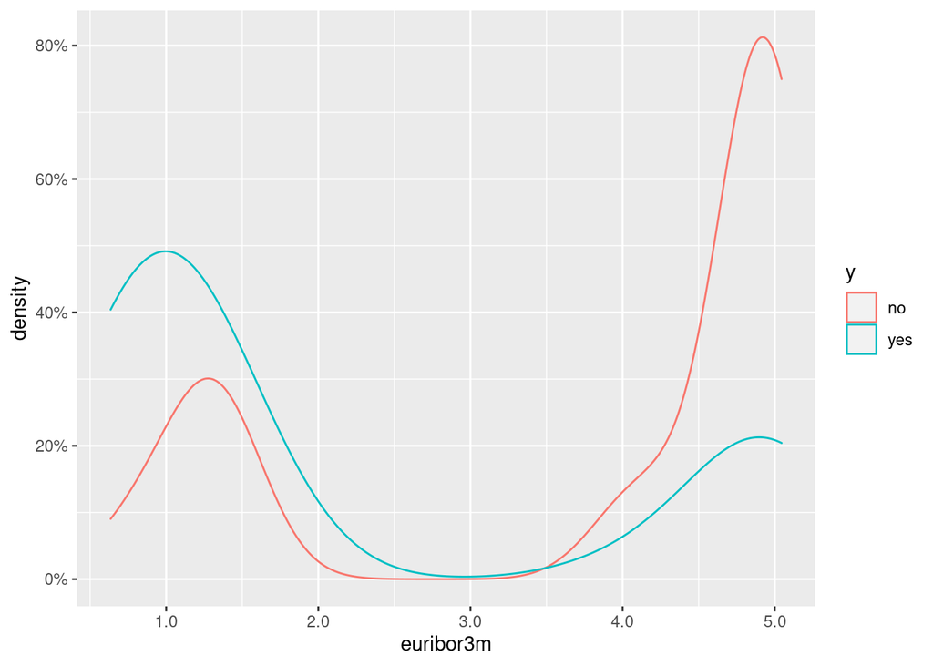

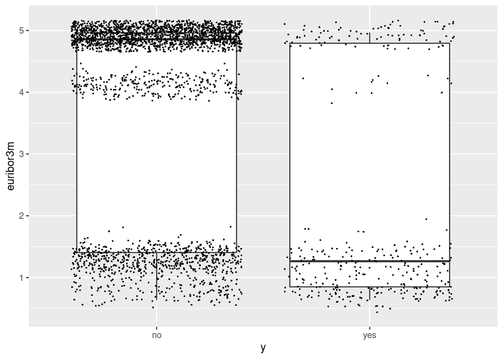

```r
ggplot(data_train, aes(x=euribor3m, color=y)) +
  geom_density() +
  scale_y_continuous(labels = scales::percent) +
  scale_x_continuous(labels = comma)

ggplot(data_train, aes(x=euribor3m, y=y)) +
  geom_boxplot() +
  coord_flip() +
  geom_jitter(shape=16, position=position_jitter(0.2), size=0.5)
```

Cuanto mayor es el euribor, menor cantidad de gente contrata, y viceversa, cuanto menor es más gente contrata. Esto podría deberse a que un menor euribor implica menores intereses en el producto contratado. El gráfico de cajas nos arroja unos resultados similares

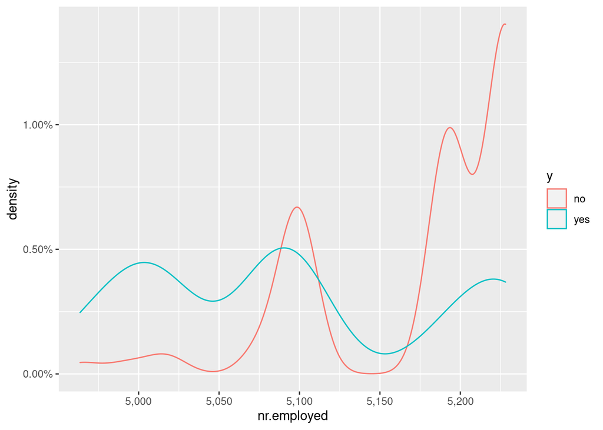

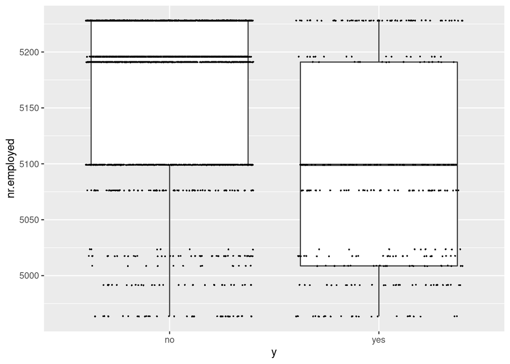

```r
ggplot(data_train, aes(x=nr.employed, color=y)) +
  geom_density() +
  scale_y_continuous(labels = scales::percent) +
  scale_x_continuous(labels = comma)

ggplot(data_train, aes(x=nr.employed, y=y)) +
  geom_boxplot() +
  coord_flip() +
  geom_jitter(shape=16, position=position_jitter(0.2), size=0.5)
```

A mayor número de emplados, menor es la cantidad de gente que contrata el producto, y viceversa. Esto puede deberse a que conforme mejores son las condiciones macroeconómicas, menor necesidad tiene la gente de contratar este tipo de productos